# Initial Models

Rage Against The Machine Learning

26/01/2021

## Covariates

We will attempt to model a response as
$$f_n(t_{k+1}) = \beta_0 + \sum_{i = 1, i \neq n}^N \beta_i f_i(t_{k+1}) + \sum_{i =1}^N\sum_{j = 1}^d \beta_{(N-1)(1+i) + j}f_i(t_{k + 1 - j})$$
$f_n(t_{k+1})$ is the value of covariate $n$ at time $t_{k+1}$. In other words: A response (vannføring) is a linear model of other covariates on the same day (precipitation, temperature, snow) and the covariates including the response for the previous days. In this way our model will capture not only the relevant paramters from the same day (assume we have a good weather forecast, so precipitation, temperature and snow is known) and relevant parameters from previous days.

The relevant parameters from previous days are: an extrapolation formula for the response and the derivatives of the different covariates.

If we consider only the response:
$$f_n(t_{k+1}) = \sum_{j =1}^d \beta_j f_n(t_{k+1-j})$$
we can interpret this as a polynomial extrapolation formula for the response $f_n$. Let $h= t_{k+1} - t_{k}$, then
$$\begin{align*}
f_n(t_{k+1}) &= f_n(t_k) + \mathcal{O}(h) \\
f_n(t_{k+1}) &= 2 f_n(t_{k}) - f_n(t_{k-1}) + \mathcal{O}(h^2) \\
&\vdots\\
f_n(t_{k+1}) &= \sum_{j =1}^d \beta_j f_n(t_{k+1-j}) + \mathcal{O}(h^d).
\end{align*}$$

For the covariates different to the response we have
$$f_m(t_{k+1}) = \sum_{i = 0}^d \beta_m f_m(t_{k+1 - i})$$
. We can interpret this as some linear combination of the different finite difference combinations possible for the covariate $m$, i.e
$$f_m(t_{k+1}) = \sum_{i =1}^d\sum_{j = 0}^d c_{q} f_m^{(i)}(t_{k+1-j}) + \mathcal{O}(h)$$
, for some $c_q$ with index $q$ given by $i$ and $j$. <The point is that fitting a linear model based on both the covariates on the same days and covariates and response for previous days we achieve some linear combination of the covariate values at those days, polynomial extrapolated values and different finite difference formulas for the different covariates at the different days.< For rivers, we would expect the water discharge to exhibit some delay in the response of the other covariates. For example, a heavy rainfall might lead to large water discharge after a couple of days as it takes time for the rainfall to travel through the soil into the river. In addition, we would expect a large change in snow (melting) will lead to large water discharge when this melted water reaches the river.

The point is that this is (hopefully) a good idea.

## Basic Models

We implement code for creating a dataframe with previous daily values as covariates and fit a linear model. First some cleaning:

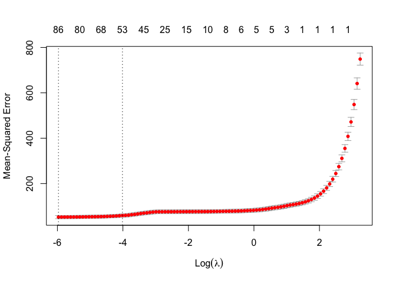

```r
# libraries
library(naniar)
library(reshape2)
library(ggplot2)
library(ggcorrplot)
library(dplyr)
library(lubridate)
library(fastDummies)
library(glmnet)
# Importing data from Eggafoss

# NOTICE DIRECTORY PATH
eggafoss <- readRDS("~/MA8701/water-shrinkage/data/raw_data_eggafoss.rds")
# NOTICE SELECT ONLY LAST 764 DAYS OF DATASET
years =40
# Fuck leap years
eggafossdf <- eggafoss[(28764 - years*365):28764, ]
names(eggafossdf)[6:8] <- c("vannføring", "vannstand", "modellertvannføring")

#Number of days we want to include
days = 20

# Which covariates we want to include
doVannstand = FALSE
doSnøvannekvivalent = TRUE
doSnødekningsgrad = TRUE
doNedbør = TRUE
doTemperatur = TRUE
doVannføring = TRUE

sumDo = doVannstand + doSnøvannekvivalent + doSnødekningsgrad + doNedbør + doTemperatur + doVannføring
names = length(names(eggafossdf))

# NOTICE the code below is some probably the worst code in the history of codes, maybe ever
# Should rewrite the if sentences into a loop but i'm too scared to change the code
for (i in 1:days){
  len = length(eggafossdf$dato)
  if (i == 1){
    do = 0
    if (doVannstand) {
      do = do + 1
      data = data.frame(c(NA,eggafossdf$vannstand[1:(len-1)]))
      eggafossdf = data.frame(c(eggafossdf, data))
      name = paste("vannstand",i,"dager",sep="")
      names(eggafossdf)[names+do] = name
    }
    if (doSnøvannekvivalent) {
      do = do + 1
      data = data.frame(c(NA,eggafossdf$snøvannekvivalent[1:(len-1)]))
      eggafossdf = data.frame(c(eggafossdf, data))
      name = paste("snøvannekvivalent",i,"dager",sep="")
      names(eggafossdf)[names+do] = name
    }
    if (doSnødekningsgrad) {
      do = do + 1
      data = data.frame(c(NA,eggafossdf$snødekningsgrad[1:(len-1)]))
      eggafossdf = data.frame(c(eggafossdf, data))
      name = paste("snødekningsgrad",i,"dager",sep="")
      names(eggafossdf)[names + do] = name
    }
    if (doNedbør) {
      do = do + 1
      data = data.frame(c(NA,eggafossdf$nedbør[1:(len-1)]))
      eggafossdf = data.frame(c(eggafossdf, data))
      name = paste("nedbør",i,"dager",sep="")
      names(eggafossdf)[names + do] = name
    }
    if (doTemperatur) {
      do = do + 1
      data = data.frame(c(NA,eggafossdf$temperatur[1:(len-1)]))
      eggafossdf = data.frame(c(eggafossdf, data))
      name = paste("temperatur",i,"dager",sep="")
      names(eggafossdf)[names + do] = name
    }
    if (doVannføring) {
      do = do + 1
      data = data.frame(c(NA,eggafossdf$vannføring[1:(len-1)]))
      eggafossdf = data.frame(c(eggafossdf, data))
      name = paste("vannføring",i,"dager",sep="")
      names(eggafossdf)[names + do] = name
    }
  }
  else {
    do = 0
    if (doVannstand) {
      do = do + 1
      data = data.frame(c(NA,eggafossdf[1:(len-1), names + (i-2)*sumDo + do]))
      eggafossdf = data.frame(c(eggafossdf, data))
      name = paste("vannstand",i,"dager",sep="")
      names(eggafossdf)[names+(i-1)*sumDo + do] = name
    }
    if (doSnøvannekvivalent) {
      do = do + 1
      data = data.frame(c(NA,eggafossdf[1:(len-1), names + (i-2)*sumDo + do]))
      eggafossdf = data.frame(c(eggafossdf, data))
      name = paste("snøvannekvivalent",i,"dager",sep="")
      names(eggafossdf)[names+(i-1)*sumDo + do] = name
    }
    if (doSnødekningsgrad) {
      do = do + 1
      data = data.frame(c(NA,eggafossdf[1:(len-1), names + (i-2)*sumDo + do]))
      eggafossdf = data.frame(c(eggafossdf, data))
      name = paste("snødekningsgrad",i,"dager",sep="")
      names(eggafossdf)[names+(i-1)*sumDo + do] = name
    }
    if (doNedbør) {
      do = do + 1
      data = data.frame(c(NA,eggafossdf[1:(len-1), names + (i-2)*sumDo + do]))
      eggafossdf = data.frame(c(eggafossdf, data))
      name = paste("nedbør",i,"dager",sep="")
      names(eggafossdf)[names+(i-1)*sumDo + do] = name
    }
    if (doTemperatur) {
      do = do + 1
      data = data.frame(c(NA,eggafossdf[1:(len-1), names + (i-2)*sumDo + do]))
      eggafossdf = data.frame(c(eggafossdf, data))
      name = paste("temperatur",i,"dager",sep="")
      names(eggafossdf)[names+(i-1)*sumDo + do] = name
    }
    if (doVannføring) {
      do = do + 1
      data = data.frame(c(NA,eggafossdf[1:(len-1), names + (i-2)*sumDo + do]))
      eggafossdf = data.frame(c(eggafossdf, data))
      name = paste("vannføring",i,"dager",sep="")
      names(eggafossdf)[names+(i-1)*sumDo + do] = name
    }
  }
}
eggafossdf = na.omit(eggafossdf)

# ADD DUMMY VARIABLES
eggafossdf <- eggafossdf %>%
  dplyr::mutate(eggafossdf, month = lubridate::month(dato))
eggafossdf$month <- factor(eggafossdf$month)
#eggafossdf <- fastDummies::dummy_cols(eggafossdf, select_columns = "month")

#SPLIT INTO TEST AND TRAINING
train_years = years - 1
len = length(eggafossdf$dato)
#Avoid data leakage by removing some days from the test set
train = eggafossdf[1:(train_years*365),]
test = eggafossdf[(train_years*365 + days):len,]

# STANDARDIZE DATA HERE



# MATRICES
x_train = model.matrix(vannføring~ . - dato - vannstand -modellertvannføring, data = train)[,-1]
y_train = train$vannføring
x_test = model.matrix(vannføring~ . - dato - vannstand -modellertvannføring, data = test)[,-1]
y_test = test$vannføring


# LINEAR FIT AND BEST SUBSET FIT WITHOUT DATE, VANNSTAND AND MODELLERTVANNFØRING
lasso = cv.glmnet(x_train, y_train, alpha = 1, standardize = TRUE)
plot(lasso)
```

```r
coef(lasso)
```

```
## 116 x 1 sparse Matrix of class "dgCMatrix"
##                                      1
## (Intercept)              -6.597203e-01
## nedbør                    1.019657e+03
## snødekningsgrad           .
## snøvannekvivalent        -6.202444e+02
## temperatur                2.247533e-01
## snøvannekvivalent1dager   4.248779e+02
## snødekningsgrad1dager     2.461513e-02
## nedbør1dager             -2.192877e+02
## temperatur1dager          .
## vannføring1dager          7.873114e-01
## snøvannekvivalent2dager   1.982896e+02
## snødekningsgrad2dager     .
## nedbør2dager              .
## temperatur2dager         -8.513374e-02
## vannføring2dager         -3.881758e-02
## snøvannekvivalent3dager   .
## snødekningsgrad3dager     .
## nedbør3dager              7.047434e+00
## temperatur3dager         -3.047129e-02
## vannføring3dager          2.048824e-02
## snøvannekvivalent4dager   .
## snødekningsgrad4dager    -5.882576e-03
## nedbør4dager              1.249916e+01
## temperatur4dager         -2.024974e-02
## vannføring4dager          6.755252e-03
## snøvannekvivalent5dager   .
## snødekningsgrad5dager     .
## nedbør5dager              2.558961e+00
## temperatur5dager         -3.900019e-03
## vannføring5dager          .
## snøvannekvivalent6dager   .
## snødekningsgrad6dager     .
## nedbør6dager              8.737640e+00
## temperatur6dager          .
## vannføring6dager          3.730480e-03
## snøvannekvivalent7dager   .
## snødekningsgrad7dager     .
## nedbør7dager             -5.167458e+00
```

[output cut: 63 more lines]

```
## snødekningsgrad20dager    .
## nedbør20dager             3.131058e+00
## temperatur20dager         .
## vannføring20dager         1.513130e-04
## month2                   -6.250192e-01
## month3                   -1.088610e+00
## month4                   -5.738252e-01
## month5                    5.758191e+00
## month6                    2.956370e+00
## month7                    8.749433e-02
## month8                    .
## month9                    1.208525e+00
## month10                   1.045889e+00
## month11                   1.341974e-01
## month12                   .
```

```r
linear = lm(vannføring~ . - dato - vannstand -modellertvannføring, data = train)
#summary(linearWithToday)
# Best subset super expensive, maybe avoid.
library(leaps)
#bestsubset = regsubsets(vannføring~ . - dato - vannstand -modellertvannføring, nvmax=60, data = train, method="backward")
#plot(summary(bestsubset)$bic, xlab = "Number of Variables", ylab = "Cp", type = 'l', main = "Cp from Backward Selection")
#coef(bestsubset,10)
#l = which.min(summary(bestsubset)$cp)
#points(l, summary(bestsubset)$cp[l], col="red", cex=3, pch=20)
#points(14, summary(bestsubset)$cp[14], col = "orange", cex = 3, pch = 20)
#summary(bestsubset)
```

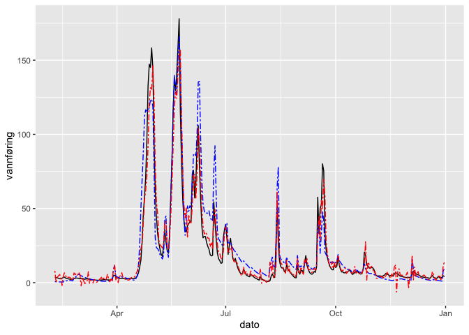

```r
library(ggplot2)
predictedLasso <- predict(lasso, newx=x_test)

#predictedLinearNoToday <- data.frame(predicted = predict(linearNoToday, test))
#predictedBestSubset <- data.frame(predicted = predict(bestsubset, eggafossdf))
ggplot(test, aes(x = dato)) + geom_line(aes(y=vannføring)) + geom_line(aes(y=modellertvannføring),color="blue",linetype="twodash") + geom_line(aes(y=predictedLasso[,1]),color="red",linetype="twodash") #+ geom_line(aes(y=predictedLinearNoToday[,]),color="green",linetype="twodash")#+ geom_line(aes(u=predictedBestSubset[,]),color="orange")
```

```r
mean((test$vannføring - test$modellertvannføring)^2)
```

```
## [1] 144.8362
```

```r
mean((test$vannføring - predictedLasso[,1])^2)
```

```
## [1] 60.31467
```

```r
#mean((test$vannføring - predictedLinearNoToday[,])^2)
```